# Lab 1 Answers: Intro to R

Dr. Ryan Johnson

2021-06-03

```r
library(tidyverse)
library(openintro)
data("arbuthnot")
```

## Exercise 1

What command would you use to extract just the counts of girls baptized? In these lab reports, also use complete sentences and the text -> code -> text -> code pattern described in the video above.

### Answer:

We would use this command:

```r
arbuthnot$girls
```

```
##  [1] 4683 4457 4102 4590 4839 4820 4928 4605 4457 4952 4784 5332 5200 4910 4617
## [16] 3997 3919 3395 3536 3181 2746 2722 2840 2908 2959 3179 3349 3382 3289 3013
## [31] 2781 3247 4107 4803 4881 5681 4858 4319 5322 5560 5829 5719 6061 6120 5822
## [46] 5738 5717 5847 6203 6033 6041 6299 6533 6744 7158 7127 7246 7119 7214 7101
## [61] 7167 7302 7392 7316 7483 6647 6713 7229 7767 7626 7452 7061 7514 7656 7683
## [76] 5738 7779 7417 7687 7623 7380 7288
```

### Grading

3 points for the correct code. 1 point for at least one sentence that uses correct grammar and punctuation. (4 points total)

```r
points = 3 + 1
```

## Exercise 2

Is there an apparent trend in the number of girls baptized over the years? How would you describe it? (To ensure that your lab report is comprehensive, be sure to include the code needed to make the plot as well as your written interpretation.)

#### Answer:

The text of answers may vary.

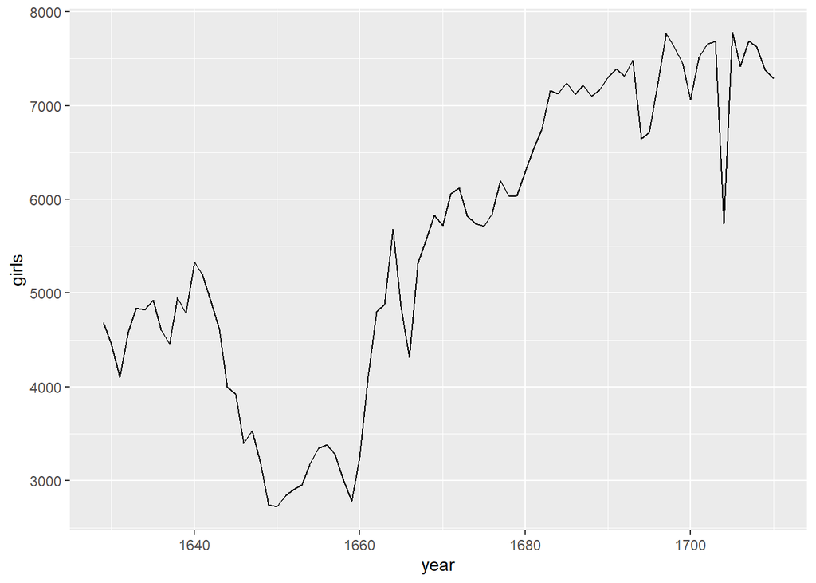

```r
ggplot(arbuthnot, aes(x = year, y = girls)) +
  geom_line()
```

### Grading

1 point for communication (complete sentences, spelling, grammar)

3 points for the plot (dot plot is also fine)

```r
points = points + 1 + 3
```